# Homework 10 — STAT 432

**Author:** Heta Patel | **Course:** STAT 432: Statistical Learning | **Software:** R (`RLT` v3.2.6, `mvtnorm`, `ggplot2`) | **Random Seed:** `432` (fully reproducible)

## Question 1: Bias-Variance Trade-Off Simulation

Two critical tuning parameters of random forests are terminal node size (`nmin`) and the candidate predictor subset size (`mtry`). This question conducts a 100-repetition simulation study to empirically assess their impact on the squared bias and variance of predicted values.

The data-generating process comprises \(p = 5\) jointly normal predictors with mean vector \(\boldsymbol{\mu} = \mathbf{0}\) and covariance matrix \(\boldsymbol{\Sigma} \in \mathbb{R}^{5 \times 5}\) satisfying \(\text{Var}(X_j) = 1\) and \(\text{Cor}(X_j, X_k) = 0.3\) for all \(j \neq k\). The scalar response is \[ Y = X_1 + X_3 + X_5 + \varepsilon, \qquad \varepsilon \sim \mathcal{N}(0, 1), \] where the noise \(\varepsilon\) is independent of the predictors. Thus, the true regression function is linear in the active predictors: \[ f(\mathbf{x}) = x_1 + x_3 + x_5, \] while \(X_2\) and \(X_4\) are uninformative noise predictors.

### 1a. Simulation Setup and Numerical Results

A fixed test set of \(N_{\text{test}} = 200\) predictor vectors was generated once from \(\mathcal{N}_5(\mathbf{0}, \boldsymbol{\Sigma})\) using pseudo-random seed `432` and held constant across all repetitions. The true target values \(f(\mathbf{x}_j) = x_{j,1} + x_{j,3} + x_{j,5}\) were evaluated once for all test points. Across \(R = 100\) independent simulation repetitions:

1. An independent training set of \(N_{\text{train}} = 200\) observations was generated from the joint distribution \((\mathbf{X}, Y)\).
2. The exact same training dataset was used to fit all tuning settings within each repetition.
3. Forests were grown to 500 trees (`ntrees = 500`), drawing a bootstrap sample of 200 observations with replacement for each tree (`replacement = TRUE, resample.prob = 1.0, reinforcement = FALSE`). All other fitting parameters remained at their package defaults.
4. Test predictions \(\hat{f}_r(\mathbf{x}_j)\) were recorded across test points \(j = 1, \dots, 200\) and repetitions \(r = 1, \dots, 100\).

For each setting, the pointwise squared bias and variance were estimated as: \[ \widehat{\text{Bias}}^2(\mathbf{x}_j) = \left( \frac{1}{R} \sum_{r=1}^R \hat{f}_r(\mathbf{x}_j) - f(\mathbf{x}_j) \right)^2, \qquad \widehat{\text{Var}}(\mathbf{x}_j) = \frac{1}{R-1} \sum_{r=1}^R \left( \hat{f}_r(\mathbf{x}_j) - \bar{\hat{f}}(\mathbf{x}_j) \right)^2, \] and subsequently averaged over the \(N_{\text{test}} = 200\) fixed test points: \[ \overline{\text{Bias}^2} = \frac{1}{200} \sum_{j=1}^{200} \widehat{\text{Bias}}^2(\mathbf{x}_j), \qquad \overline{\text{Var}} = \frac{1}{200} \sum_{j=1}^{200} \widehat{\text{Var}}(\mathbf{x}_j), \qquad \overline{\text{MSE}} = \overline{\text{Bias}^2} + \overline{\text{Var}}. \]

#### Comparison 1: Varying Node Size (`nmin`) with `mtry = 3` Fixed

Fixing `mtry = 3`, we vary terminal node size `nmin` \(\in \{1, 5, 10, 20, 30\}\). Table 1 reports the averaged metrics across the 200 test points, and Figure 1 illustrates the bias-variance trade-off curve.

Table 1: Averaged Squared Bias, Variance, and Total MSE vs. Node Size (mtry = 3, 100 repetitions)

| Node Size (`nmin`) | Averaged Squared Bias | Averaged Variance | Averaged Total MSE |
| --- | --- | --- | --- |
| 1 | 0.3157 | 0.1056 | 0.4213 |
| 5 ★ (Minimum MSE) | 0.3227 | 0.0938 | 0.4165 |
| 10 | 0.3626 | 0.0757 | 0.4383 |
| 20 | 0.4794 | 0.0587 | 0.5381 |
| 30 | 0.6054 | 0.0525 | 0.6579 |

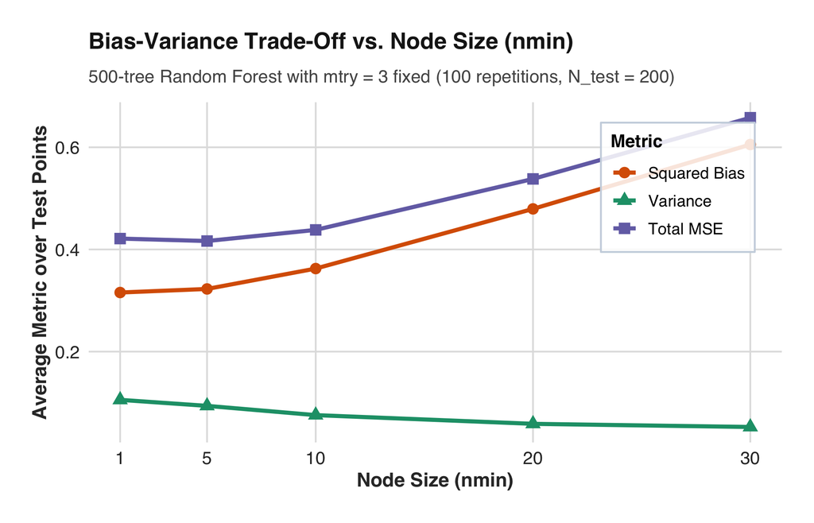

Figure 1: Averaged squared bias, variance, and total MSE across 200 fixed test points vs. node size (nmin), with mtry = 3 fixed. Styled following STAT 432 plot formatting guidelines.

#### Comparison 2: Varying Candidate Predictors (`mtry`) with `nmin = 10` Fixed

Fixing `nmin = 10`, we vary candidate split predictors `mtry` \(\in \{1, 2, 3, 4, 5\}\). Table 2 reports the averaged metrics, and Figure 2 presents the corresponding curves.

Table 2: Averaged Squared Bias, Variance, and Total MSE vs. Candidate Predictors (nmin = 10, 100 repetitions)

| Candidate Predictors (`mtry`) | Averaged Squared Bias | Averaged Variance | Averaged Total MSE |
| --- | --- | --- | --- |
| 1 | 0.9068 | 0.0362 | 0.9430 |
| 2 | 0.4697 | 0.0573 | 0.5271 |
| 3 | 0.3626 | 0.0757 | 0.4383 |
| 4 | 0.3163 | 0.0922 | 0.4085 |
| 5 ★ (Minimum MSE) | 0.2935 | 0.1066 | 0.4000 |

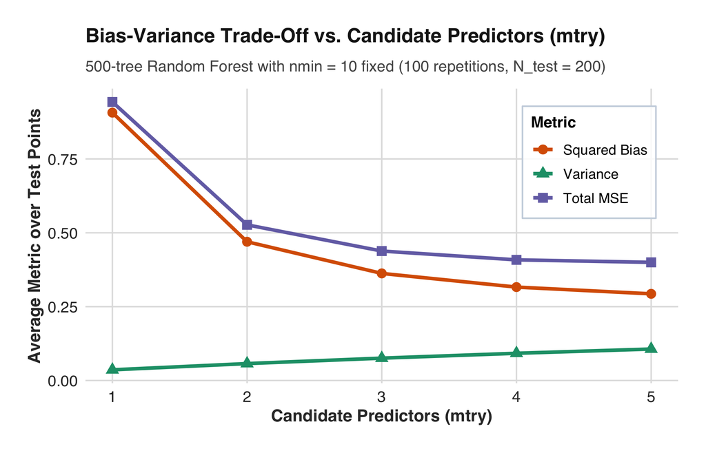

Figure 2: Averaged squared bias, variance, and total MSE across 200 fixed test points vs. candidate predictors (mtry), with nmin = 10 fixed.

### 1b. Discussion of the Bias-Variance Trade-Off

#### 1. How does a large node size, such as 30, affect the fit in this example?

The node size parameter (`nmin`) determines the stopping rule for recursive partitioning: nodes containing at most `nmin` observations are not split further. As `nmin` increases from 1 to 30:

- **Substantial Increase in Squared Bias:** At `nmin = 1`, the averaged squared bias is **0.3157**. When `nmin` is increased to 30, squared bias nearly doubles, rising to **0.6054** (+91.8%). A large node size forces trees to terminate early at shallow depths, partitioning the predictor space into very broad geometric cells. Averaging the training responses across these large regions smooths out the genuine linear gradient \(x_1 + x_3 + x_5\), inducing severe underfitting.
- **Modest Reduction in Variance:** Concurrently, the variance decreases monotonically from **0.1056** at `nmin = 1` down to **0.0525** at `nmin = 30` (−50.3%). Larger terminal nodes average over more training observations, dampening the sensitivity of individual leaf predictions to training noise \(\varepsilon\).
- **Net Degradation in Total MSE:** Because the increase in squared bias (+0.2897) far exceeds the variance reduction (−0.0531), the overall prediction MSE deteriorates from its minimum of **0.4165** (at `nmin = 5`) to **0.6579** at `nmin = 30` (+58.0%). In this additive linear regression setting, over-regularizing terminal leaf size severely hurts predictive performance.

#### 2. What are the benefits and drawbacks of using a large `mtry` value?

- **Benefits of Large `mtry` (Dramatic Bias Reduction):** In this model, only 3 of the 5 predictors (\(X_1, X_3, X_5\)) carry true signal, while \(X_2\) and \(X_4\) are pure noise. When `mtry = 1`, every split must use whatever single variable is randomly selected. In 40% of splits, an uninformative noise variable is chosen, and in the remaining 60%, only one active variable is available without the ability to optimize split choice. This generates weak, poorly oriented splits, resulting in an enormous squared bias (**0.9068**). As `mtry` increases to 5, every split can evaluate all active predictors, enabling trees to reliably split on the most informative features and slashing squared bias by 67.6% down to **0.2935**.
- **Drawbacks of Large `mtry` (Variance Inflation via Tree Correlation):** The variance of a random forest ensemble of \(B\) trees is: \[ \text{Var}(\hat{f}_{\text{RF}}(\mathbf{x})) = \rho(\mathbf{x}) \sigma^2(\mathbf{x}) + \frac{1 - \rho(\mathbf{x})}{B} \sigma^2(\mathbf{x}), \] where \(\sigma^2(\mathbf{x})\) is the variance of a single tree and \(\rho(\mathbf{x})\) is the pairwise correlation between trees. When `mtry` is large, individual trees repeatedly select the same dominant features (\(X_1, X_3, X_5\)) at top-level splits. This causes the trees to become highly correlated (\(\rho \to 1\)), drastically limiting the ensemble's ability to average out estimation errors. As a result, ensemble variance rises from **0.0362** at `mtry = 1` to **0.1066** at `mtry = 5` (+194.8%).
- **Net Trade-Off:** Because the linear additive signal is strong across three predictors, the massive reduction in squared bias (−0.6133) comfortably outweighs the variance inflation (+0.0704), driving total MSE down from **0.9430** at `mtry = 1` to **0.4000** at `mtry = 5`. In problems with many noise predictors or complex nonlinear interactions, intermediate values of `mtry` (e.g. \(\lfloor \sqrt{p} \rfloor\) or \(p/3\)) typically strike the best balance.

#### 3. If each tree instead sampled 100 observations with replacement, would you expect the preferred node size to shift toward smaller or larger values?

When each tree draws a bootstrap sample of only \(n_{\text{sub}} = 100\) observations instead of 200:

1. **Shallower Trees Accelerate Bias Inflation:** With only 100 observations per tree, sample mass at each split is halved. If a large node size such as `nmin = 20` or `30` is retained, trees can execute at most 2 or 3 splits before terminal node sizes fall below `nmin`. This causes premature termination, flattening tree depth and causing squared bias to spike sharply (reaching **0.9979** at `nmin = 30`).
2. **Subsampling Reduces Tree Correlation:** Drawing smaller subsamples of 100 observations with replacement injects additional randomization, lowering pairwise tree overlap and reducing between-tree correlation \(\rho\). Consequently, forest variance is naturally low (ranging from **0.0776** at `nmin = 1` to **0.0398** at `nmin = 30`).
3. **Shift to Smaller Preferred Node Size:** Because variance is already well-controlled by subsampling, the dominant contributor to overall error becomes squared bias. To allow the shallower trees to capture adequate function complexity, trees must be allowed to split deeper by adopting **smaller terminal node sizes**.

To confirm this reasoning, we ran an additional simulation across 100 repetitions with \(n_{\text{sub}} = 100\) observations sampled with replacement per tree (`resample.prob = 0.5` in RLT). Table 3 and Figure 3 report the empirical results:

Table 3: Additional Simulation — Subsampling 100 Observations with Replacement per Tree (mtry = 3, 100 repetitions)

| Node Size (`nmin`) | Averaged Squared Bias | Averaged Variance | Averaged Total MSE |
| --- | --- | --- | --- |
| 1 ★ (Minimum MSE) | 0.4211 | 0.0776 | 0.4987 |
| 5 | 0.4377 | 0.0658 | 0.5035 |
| 10 | 0.5239 | 0.0537 | 0.5776 |
| 20 | 0.7535 | 0.0434 | 0.7968 |
| 30 | 0.9979 | 0.0398 | 1.0377 |

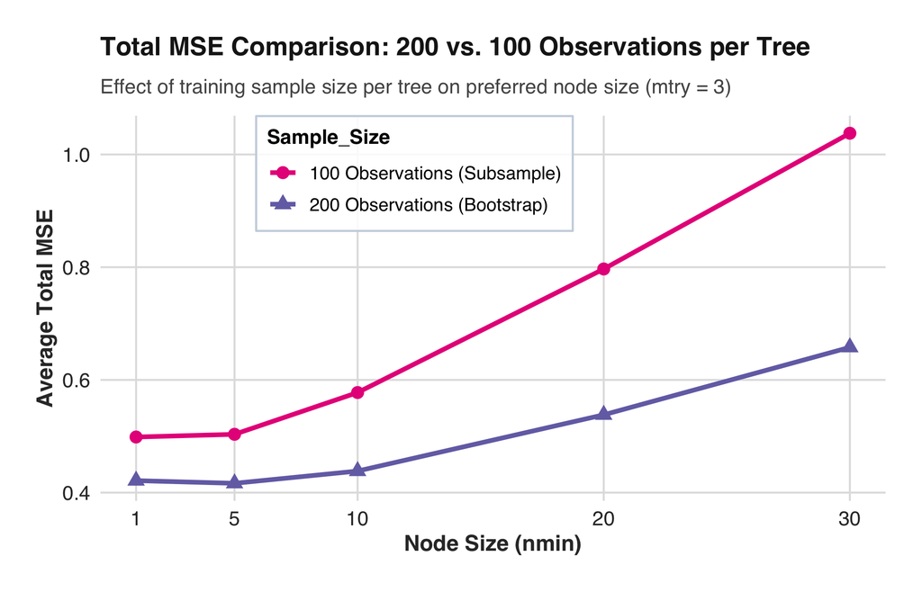

Figure 3: Total MSE comparison across node size settings between full bootstrap (200 observations) and subsampling (100 observations). The optimal node size shifts from nmin = 5 to nmin = 1.

**Conclusion:** With full bootstrap sampling (\(N = 200\)), the preferred node size is `nmin = 5` (MSE = 0.4165). When sampling 100 observations per tree, the preferred node size shifts toward smaller values, reaching its minimum at **`nmin = 1`** (MSE = 0.4987). This confirms that smaller tree training sample sizes shift the preferred node size toward smaller values to combat premature stopping and excessive bias.

## Question 2: Tuning Random Forests for MNIST

We analyze `mnist-first2000.csv.gz`, which contains 2,000 MNIST observations across 784 pixel features and digit labels:

- **Data Splitting:** From the first 1,000 observations, digits 1, 6, and 7 were retained as the training set (\(N_{\text{train}} = 327\), containing 116 ones, 94 sixes, and 117 sevens). From the remaining 1,000 observations, digits 1, 6, and 7 formed the test set (\(N_{\text{test}} = 317\), containing 104 ones, 106 sixes, and 107 sevens).
- **PCA Preprocessing:** Principal Component Analysis was fitted strictly to the training pixel matrix, centering pixels by their training means without scaling (`prcomp(train_pixels, center = TRUE, scale. = FALSE)`). The first 20 principal components were extracted as predictors. Test observations were projected using the identical training means and loadings: \(\mathbf{X}_{\text{test}} = (\mathbf{X}_{\text{test, raw}} - \bar{\mathbf{x}}_{\text{train}}) \mathbf{V}_{20}\).
- **Forest Architecture:** RLT classification forests with 1,000 trees (`ntrees = 1000`), drawing bootstrap samples of size \(N = 327\) with replacement (`replacement = TRUE, resample.prob = 1.0, reinforcement = FALSE`).

### 2b. Hyperparameter Grid Tuning and Variable Importance

We evaluated a 42-point grid crossing candidate split predictors `mtry` \(\in \{2, 4, 6, 8, 12, 16, 20\}\) with terminal node size `nmin` \(\in \{1, 2, 5, 10, 15, 20\}\). Table 4 reports the complete grid evaluations, and Figure 4 provides a heatmap of the ensemble OOB error rates.

Table 4: Hyperparameter Grid Tuning for MNIST Random Forest (1,000 Trees, 327 Training Instances)

| Setting | `mtry` | `nmin` | Ensemble OOB Error | Ensemble OOB Error (%) | Tree-Average OOB Error |
| --- | --- | --- | --- | --- | --- |
| 1 | 2 | 1 | 0.0214 | 2.14% | 0.3254 |
| 2 | 4 | 1 | 0.0306 | 3.06% | 0.2314 |
| 3 | 6 | 1 | 0.0336 | 3.36% | 0.1904 |
| 4 | 8 | 1 | 0.0275 | 2.75% | 0.1623 |
| 5 | 12 | 1 | 0.0306 | 3.06% | 0.1289 |
| 6 | 16 | 1 | 0.0398 | 3.98% | 0.1121 |
| 7 | 20 | 1 | 0.0336 | 3.36% | 0.1014 |
| 8 | 2 | 2 | 0.0245 | 2.45% | 0.3211 |
| 9 | 4 | 2 | 0.0275 | 2.75% | 0.2371 |
| 10 | 6 | 2 | 0.0306 | 3.06% | 0.1879 |
| 11 | 8 | 2 | 0.0275 | 2.75% | 0.1650 |
| 12 | 12 | 2 | 0.0428 | 4.28% | 0.1281 |
| 13 | 16 | 2 | 0.0336 | 3.36% | 0.1105 |
| 14 | 20 | 2 | 0.0336 | 3.36% | 0.0993 |
| 15 ★ (Selected Model) | 2 | 5 | 0.0183 | 1.83% | 0.3325 |
| 16 | 4 | 5 | 0.0306 | 3.06% | 0.2414 |
| 17 | 6 | 5 | 0.0367 | 3.67% | 0.1948 |
| 18 | 8 | 5 | 0.0306 | 3.06% | 0.1641 |
| 19 | 12 | 5 | 0.0367 | 3.67% | 0.1332 |
| 20 | 16 | 5 | 0.0367 | 3.67% | 0.1131 |
| 21 | 20 | 5 | 0.0367 | 3.67% | 0.1039 |
| 22 | 2 | 10 | 0.0245 | 2.45% | 0.3401 |
| 23 | 4 | 10 | 0.0367 | 3.67% | 0.2497 |
| 24 | 6 | 10 | 0.0306 | 3.06% | 0.2020 |
| 25 | 8 | 10 | 0.0367 | 3.67% | 0.1731 |
| 26 | 12 | 10 | 0.0398 | 3.98% | 0.1345 |
| 27 | 16 | 10 | 0.0398 | 3.98% | 0.1162 |
| 28 | 20 | 10 | 0.0428 | 4.28% | 0.1057 |
| 29 | 2 | 15 | 0.0245 | 2.45% | 0.3511 |
| 30 | 4 | 15 | 0.0306 | 3.06% | 0.2584 |
| 31 | 6 | 15 | 0.0367 | 3.67% | 0.2070 |
| 32 | 8 | 15 | 0.0428 | 4.28% | 0.1794 |
| 33 | 12 | 15 | 0.0428 | 4.28% | 0.1385 |
| 34 | 16 | 15 | 0.0367 | 3.67% | 0.1157 |
| 35 | 20 | 15 | 0.0428 | 4.28% | 0.1036 |
| 36 | 2 | 20 | 0.0306 | 3.06% | 0.3553 |
| 37 | 4 | 20 | 0.0336 | 3.36% | 0.2652 |
| 38 | 6 | 20 | 0.0428 | 4.28% | 0.2142 |
| 39 | 8 | 20 | 0.0367 | 3.67% | 0.1795 |
| 40 | 12 | 20 | 0.0428 | 4.28% | 0.1431 |
| 41 | 16 | 20 | 0.0520 | 5.20% | 0.1203 |
| 42 | 20 | 20 | 0.0459 | 4.59% | 0.1080 |

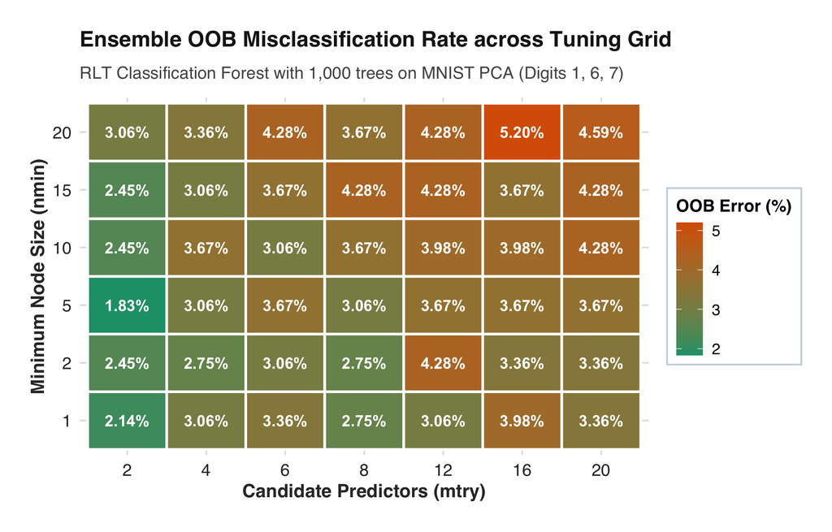

Figure 4: Heatmap of Ensemble Out-of-Bag (OOB) Misclassification Rate across all 42 grid combinations of mtry and nmin.

**Selected Tuning Configuration:**  
• **Selected Setting:** `mtry = 2`, `nmin = 5`.  
• **Ensemble OOB Misclassification Rate:** **0.0183** (**1.83%**; only 6 misclassified out of 327 observations).  
• **Tree-Average OOB Error:** 0.3325 (33.25%).  
*Note:* If selected by tree-average OOB error, the best configuration is `mtry = 20, nmin = 2` (tree OOB = 0.0993). However, its ensemble OOB error is 0.0336 (nearly twice as many misclassifications) because setting `mtry = 20` forces all trees to choose identical splits, eliminating ensemble diversity. The ensemble OOB rate directly evaluates the actual voting classifier.

#### OOB Permutation Variable Importance

For the selected model (`mtry = 2, nmin = 5`), we extracted the out-of-bag permutation variable importance for all 20 principal components. Table 5 and Figure 5 present the ranked results.

Table 5: OOB Permutation Variable Importance for the 20 Principal Components (Selected Model: mtry = 2, nmin = 5)

| Rank | Principal Component | OOB Permutation Importance | Relative Contribution |
| --- | --- | --- | --- |
| 1 | **PC2** | 0.4506 | 100.0% |
| 2 | **PC1** | 0.3261 | 72.4% |
| 3 | **PC5** | 0.0950 | 21.1% |
| 4 | **PC6** | 0.0899 | 20.0% |
| 5 | **PC3** | 0.0881 | 19.5% |
| 6 | **PC7** | 0.0664 | 14.7% |
| 7 | **PC4** | 0.0571 | 12.7% |
| 8 | **PC11** | 0.0562 | 12.5% |
| 9 | **PC18** | 0.0488 | 10.8% |
| 10 | **PC16** | 0.0470 | 10.4% |
| 11 | **PC10** | 0.0458 | 10.2% |
| 12 | **PC12** | 0.0453 | 10.1% |
| 13 | **PC14** | 0.0435 | 9.7% |
| 14 | **PC13** | 0.0367 | 8.1% |
| 15 | **PC9** | 0.0365 | 8.1% |
| 16 | **PC8** | 0.0355 | 7.9% |
| 17 | **PC15** | 0.0330 | 7.3% |
| 18 | **PC20** | 0.0311 | 6.9% |
| 19 | **PC17** | 0.0297 | 6.6% |
| 20 | **PC19** | 0.0255 | 5.7% |

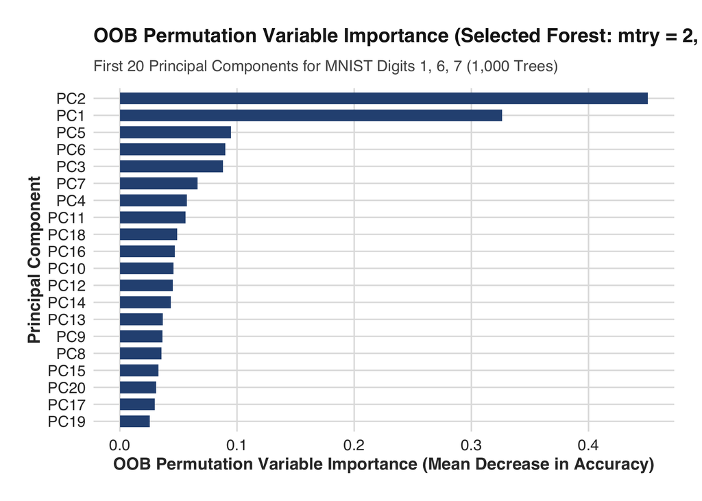

Figure 5: Ranked OOB permutation variable importance of the 20 principal components for classifying MNIST digits 1, 6, and 7.

### 2c. Test Evaluation & Confusion Matrix

The selected model (`mtry = 2, nmin = 5`) was applied to the 317 independent test observations. Test labels were used strictly for this final assessment. Table 6 reports the resulting test confusion matrix.

Table 6: Confusion Matrix on Test Data (Selected Model: mtry = 2, nmin = 5)

[output not shown]

## Question 3: Planning a Random-Forest Analysis Skill

### 3a. Design Philosophy & Balancing Instructions

When designing a random-forest analysis skill for an AI agent, the goal is to provide high-level architectural constraints and personal methodological choices without micromanaging standard routine mechanics that a capable model already understands. Because modern LLMs readily comprehend textbook random-forest fundamentals (e.g., recursive binary partitioning, impurity minimization, and bagging), overloading a skill with elementary syntax often causes rigidity, verbosity, or brittle code execution. Instead, the skill should balance standard practices with personal requirements by establishing strict foundational safeguards—such as leak-free data partitioning, fixed pseudo-random seeds, and appropriate candidate parameter grids (`mtry` spanning $[1, p]$ and terminal node size `nmin`)—while focusing its primary guidance on user-specific analytical priorities. These personal choices include requiring out-of-bag permutation importance rather than biased Gini impurity metrics, enforcing a strictly budgeted one-page executive summary in 11-point typography, commanding a publication-ready color-blind safe aesthetic (`#1b9e77`, `#d95f02`, `#7570b3`) with embedded base64 graphics, and demanding substantive domain interpretation of feature effects over generic boilerplate. For a capable AI, this division leverages its native statistical competence while reliably steering the final analysis toward the user’s exact methodological, visual, and reporting standards.

### 3b. 10 Ordered Instructions (from Basic to Personal Preferences)

1. 1. Problem Formulation & Data Type Validation (Basic Machine Learning) Inspect and validate the input dataset, confirm target variable type (continuous for regression, factor/discrete for classification), encode categorical predictors appropriately, and verify that no missing values exist before fitting.
2. 2. Strict Data Leakage Prevention (Foundational Methodology) Partition the data into training and held-out test sets prior to any analysis; fit all preprocessing transformations (e.g., centering, scaling, PCA, or imputation) strictly on training observations and apply identical transformations to test observations without snooping.
3. 3. Reproducibility Standard (Computational Integrity) Explicitly set, document, and report a fixed pseudo-random seed before generating data splits, bootstrap resamples, or running stochastic forest algorithms.
4. 4. Ensemble Architecture & Bootstrap Sampling (Algorithmic Core) Construct random forests with at least 500 to 1,000 trees to ensure asymptotic variance stabilization, drawing bootstrap samples of size \(N\) with replacement (\(n_{\text{sub}} = N\)) for each individual tree.
5. 5. Systematic Hyperparameter Tuning Grid (Model Optimization) Tune candidate splitting predictors (`mtry`) across a wide range (including \(\lfloor\sqrt{p}\rfloor\), \(p/3\), and boundary values) and terminal node size (`nmin`), comparing candidate settings using out-of-bag (OOB) misclassification rate or cross-validation rather than in-sample training error.
6. 6. Diagnostic Error Reporting (Statistical Diagnostics) Report both individual tree out-of-bag error and the aggregated ensemble out-of-bag prediction error, providing a complete confusion matrix and per-class error breakdown for classification.
7. 7. Permutation-Based Variable Importance (Feature Attribution Preference) Quantify predictor importance using out-of-bag permutation feature importance (mean decrease in accuracy/MSE) rather than split-based Gini impurity decrease to prevent bias toward continuous or high-cardinality features.
8. 8. Clean Table Presentation & Formatting (Stylistic Preference) Present hyperparameter tuning grids, confusion matrices, and ranked feature importances in clean, high-contrast HTML/Markdown tables with the optimal configuration highlighted and numerical values formatted to 3–4 decimal places.
9. 9. Publication-Quality Plot Aesthetic (Visual Preference) Produce self-contained 7 × 4.5 inch diagnostic plots with clean sans-serif typography (`Helvetica`/`Inter`), color-blind safe palettes (`#1b9e77`, `#d95f02`, `#7570b3`), subtle gridlines (`#e0e0e0`), and embedded data URIs or inline SVGs following STAT 432 visual guidelines.
10. 10. One-Page Executive Synthesis & Limitation Critique (Personal Reporting Standard) Summarize the final model findings in an executive report strictly constrained to at most one printed page (11-point font), discussing the geometric or substantive interpretation of the top-ranked features, practical trade-offs of the chosen tuning parameters, and explicit analytical limitations.

STAT 432: Statistical Learning • Homework 10 • Self-contained HTML report with reproducible R solutions.